# Spring Summative

Katherine Millar

### Investigating the effect of rnai treatment on the longevity of c elegans

### Introduction

*Caenorhabditis elegans* are a widely used as a model organism in biology. They are often used to test for epigenetic effects, and how the life history of the parents of the c.elegans will affect their offspring. Both the longevity and fertility of organisms are influenced by both diverse genetic and environmental factors (Hamilton et al, 2005). Stress can be an influential factor on longevity in organisms, as well as fertility. There have been previous studies into how particular rnai treatments such as using the raga-1 gene, can affect both longevity and reproduction in the *c. elegans* (nematode worm). raga-1 is the (main) gene involved in the determination of adult lifespan (WormBase, 2022).

I hypothesise that the raga-1 gene being the dsDNA target gene will therefore have a direct effect on decreasing how many offspring a *c.elegans* will have as well as decreasing longevity both in themselves and in their offspring.

Mini hypothesisises

1. f0 knockdown gene with treatment has an affect on their longevity
2. f0 knockdown gene with treatment has an affect on their reproduction
3. f0 knockdown gene with treatment has affect on offsprings longevity
4. f0 knockdown gene with treatment has affect on offsprings reproduction

f0 - does stress (light) have an affect on their own longevity

model 1 - f0 lifespan based on THEIR rnai gene and treatment f0 - longevity, rnai, treatment (tick)

model 2 - f0 longevity based on whether THEY were in light/dark f0 - longevity, treatment (tick)

model 3 - f0 amount of offspring based on rnai gene and treatment f0 - offspring, rnai, treatment (tick)

model 4 - f1 longevity based on their parent’s rnai and parents treatment f1 - longevity, parent’s rnai, parent’s treatment (tick)

model 5 - f1 offspring vs their parents rnai and treatment f1 - offspring, parent’s rnai, parent’s treatment (tick)

model 6 - f1 longevity based on their treatment and their parent’s treatment f1 - longevity, parental treatment and treatment (tick)

model 7 - f1 longevity with their treatment and replicate f1 longevity, treatment, plate (tick)

C elegans are known to develop over 3-4 days when in the laboratory (at 20 degree temperatures). Work by Schreiber et al, 2010 into looking at the raga-1 gene as an aging modulator has shown that c elegans that were engineered with the ‘gain of function’ active raga-1 had a shortened lifespan while a mutant ‘dominant negative’ raga-1 lengthened lifespan.

## Method

Replicates were performed for each of f0 and f1 generation reproduction, and for f0 and f1 lifespan. for f0 reproduction, there were 47 different replicates for a dark treatment, and 14 different replicates for a light treatment. for f0 lifespan, there were 6 different replicates for dark, and 5 different replicates for a light treatment. for f1 reproduction, there were 15 replicates for both light and dark treatment. for f1 lifespan, there were 6 replicates for both light and dark treatment.

# Results and Discussion

The conditions in which the nematode worm lived in, and what gene treatment it received is said to affect the worm’s longevity. There is debate into whether the nematode worms living coniditons, like living in light, stressful conditions or dark, like in the soil.

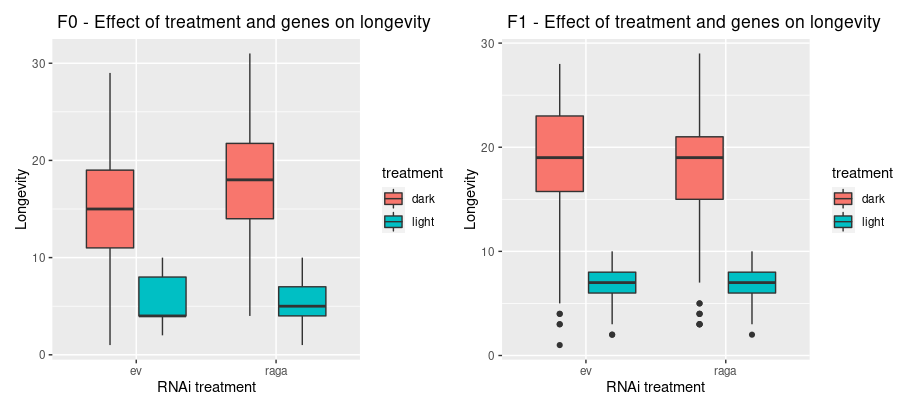

A nematode worm usually lives best in dark conditions, as they are adapted to live in the soil. Conditions other than this, such as light conditions can be stated as a stressful condition and could be considered a factor for shorter longevity.

# Hypothesis 1 -

The hypothesis that stressful conditions in the f0 generation have an affect on their on longevity was tested

Previous research has indicated that there is a relation of stressful conditions and longevity of the nematode worm. Although, a connection between the two is known, the data for the exact reasons behind this is skewed (Zhou et al, 2011). A factor to be considered, with nematodes, which are able to withstand an true affect of aging from stress, are known to have resistance to increased stress resistance.

There was a significant overall effect on the longevity of the nematode worm of the f0 generation (Linear model:*P*=2.66^-77 ) with dark treatment to light treatment.

A model which looked at the longevity of f0 was created based on whether or not they lived in light or dark conditions, as well as what gene knockdown treatment they had.

There was a reason to keep the interaction effect (F= 0.006), and was kept in the model.

It was found that there was a significant difference for dark treatment and light treatment (F, -15.4, *P*=4.97^-42). There was significant difference in empty vector rnai treatment and raga-1 rnai treatment (F, 4.09, *P*=5.21^-5).

There was a significant effect on empty vector rnai and dark treatment to rnai raga-1 and light treatment (F-2.75, P=6.23^-3).

# Hypothesis 2 -

The hypothesis that f0’s reproduction would be affected by their lifestyle was created.

A model which looked at the amount of offspring the f0 generation had versus the rnai gene knockdown treatment they had, as well as if they lived in dark or light conditions was created.

There is no significance when looking at the difference in offspring produced from rnai raga and rnai empty vector (F, 19 , P= 0.56). There is a high amount of significance when looking at the amount of offspring f0 generation had when comparing dark treatment and light treatment (F, -3.1O , P=0.0).

### Hypothesis 3 -

The hypothesis that the longevity of f0 generation’s offspring would be affected by both their rnai gene and treatment was created.

It was found that there was a small interaction effect between parental rnai and parental treatment, but it was not significantly different from no effect (P=0.75), so therefore was dropped from the model.

There was no significance when comparing the longevity of the f1 offspring based on their parent’s rnai. (F, = -0.90, P=0.371),It was found that, 95% Confidence Interval (1.6-0.6). when comparing ev gene with raga gene. There was no statistical significance when comparing parental dark treatment with parental light treatment (F, -0.13, P=0.90). This shows that the treatment and gene which the parent’s of f1 generation were knocked down with did not have a direct affect on their longevity.

# References

Hamilton, B., Dong, Y., Shindo, M., Liu, W., Odell, I., Ruvkun, G. and Lee, S.S., 2005. A systematic RNAi screen for longevity genes in C. elegans. Genes & development, 19(13), pp.1544-1555.

Wormbase.org. 2022. raga-1 (gene) - WormBase : Nematode Information Resource. [online] Available at: https://wormbase.org/species/c_elegans/gene/WBGene00006414?redirect=1#0-9f-10 [Accessed 5 May 2022].

Zhou, K.I., Pincus, Z. and Slack, F.J., 2011. Longevity and stress in Caenorhabditis elegans. Aging (Albany NY), 3(8), p.733.